# Dobór skali kolorów na wizualizacjach

Jan Pieczywok

## Opis zagadnienia

W eksperymencie chcemy zbadać w praktyce, jak **wybór skali barw** wpływa na interpretację przedstawionych danych i może prowadzić do **błędnych wniosków**. Badamy efekt percepcji barw - odbiorcy mogą błędnie przypisywać większe różnice liczbowe miejscom, gdzie kolory na mapie różnią się mocno wizualnie — nawet jeśli wartości są zbliżone. Skale niemonotoniczne, takie jak tęczowa, mogą zatem wprowadzać złudzenie ostrych granic i utrudniać prawidłowe określenie wartości skrajnych, ponieważ brak w nich jednoznacznego kierunku narastania koloru (np. od jasnego do ciemnego). To może powodować problemy w szybkim rozpoznaniu obszarów z najwyższymi lub najniższymi wartościami.

Skupimy się na porównaniu dwóch podejść do wizualizacji tych samych danych geograficznych:

- **Wizualizacja zgodna z percepcją ludzkiego oka:**  
  wykorzystuje ciągłą skalę kolorów, w której zmiany barwy odpowiadają proporcjonalnym zmianom wartości danych. Kolory są ułożone tak, aby były jednoznacznie interpretowalne percepcyjnie – najczęściej od jasnych (niższe wartości) do ciemnych (wyższe wartości).
- **Wizualizacja wielobarwna (tęczowa):**  
  oparta na niemonotonicznej skali kolorów, przechodzącej przez wiele różnych odcieni.  
  Taka skala może sugerować nieistniejące ostre granice lub różnice w danych, potencjalnie wprowadzając odbiorcę w błąd.

## Cel

Celem eksperymentu jest ustalenie, czy w przypadku danych ciągłych z relacją porządkową zastosowanie skali barw o **monotonnie** zmieniającym się natężeniu, w **ograniczonym** zakresie (powrzechnie uznawana za stosowną metodę przy tego typu wizualizacjach) ułatwi poprawną interpretację danych z mapy w porównaniu z zastosowaniem **wielobarwnej**, **niemonotonicznej** (tutaj tęczowej) skali kolorów. Koncentrujemy się na efektywności identyfikowania wartości skrajnych oraz zdolności porównywania wartości między poszczególnymi regionami.

## Opis eksperymentu

Eksperyment przeprowadzamy na grupie 15 osób. Uczestnikom prezentujemy dwie mapy przedstawiające liczbę morderstw na 100 tysięcy mieszkańców w różnych stanach USA (na podstawie wbudowanej ramki danych “Usarrests”).

Na obu wersjach mapy dodatkowo zaznaczamy przez “X” i “Y” odpowiednio stany Północną Dakotę i Maine.

Następnie uczestnicy odpowiadają na poniższe pytania:

1. Czy mapa A sugeruje, że liczba morderstw w stanach X i Y znacząco się różni?
2. Czy mapa B sugeruje, że liczba morderstw w stanach X i Y znacząco się różni?
3. Na której mapie łatwiej jest Ci zidentyfikować stany o najwyższej i najniższej liczbie morderstw?
4. Na której mapie szybciej odczytałeś dane potrzebne do odpowiedzi na powyższe pytania?
5. Kolorystyka której z dwóch map wydaje Ci się estetycznie ładniejsza?

Ankietę przeprowadzamy za pomocą Google Forms ([link](https://docs.google.com/forms/d/e/1FAIpQLSdefPbrKeX0KUsAUyNFycdFMybf74qHmxDMmNcMzGT1hZbfxA/viewform)). Poniżej przedstawiam wizualizacje, które były ze sobą porównywane.

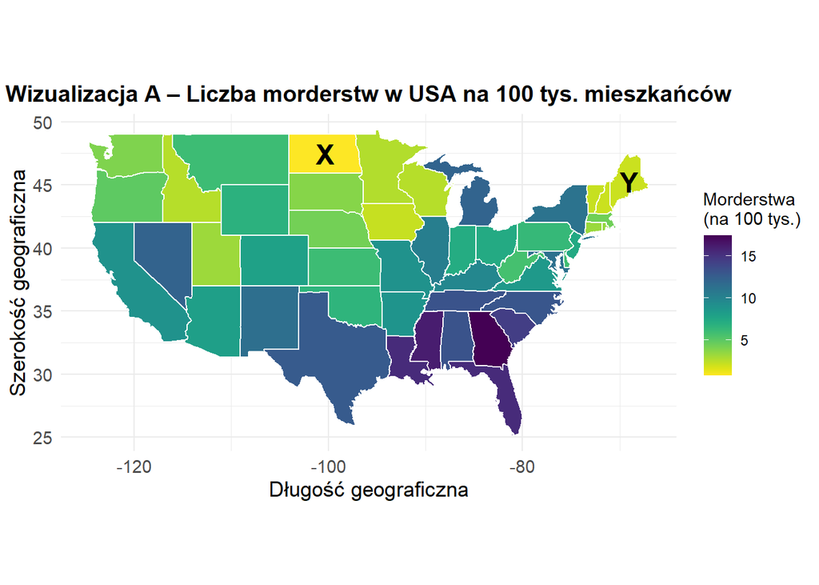

```r
ggplot(mapa_df, aes(long, lat, group = group, fill = Murder)) +
  geom_polygon(color = "white") +
  coord_fixed(1.3) +
  scale_fill_viridis(
    option = "D",
    direction = -1,
    name = "Morderstwa\n(na 100 tys.)"
  ) +
  labs(title = "Wizualizacja A – Liczba morderstw w USA na 100 tys. mieszkańców",
    x = "Długość geograficzna",
    y = "Szerokość geograficzna") +
  geom_text(
    data = punkty,
    aes(x = long, y = lat, label = label),
    inherit.aes = FALSE,
    size = 6, fontface = "bold", color = "black"
  ) +
  theme_minimal() +
  theme(
  plot.title = element_text(size = 14, face = "bold", hjust = 0.5),
  axis.title.x = element_text(size = 13),
  axis.title.y = element_text(size = 13),
  axis.text.x = element_text(size = 11),
  axis.text.y = element_text(size = 11))
```

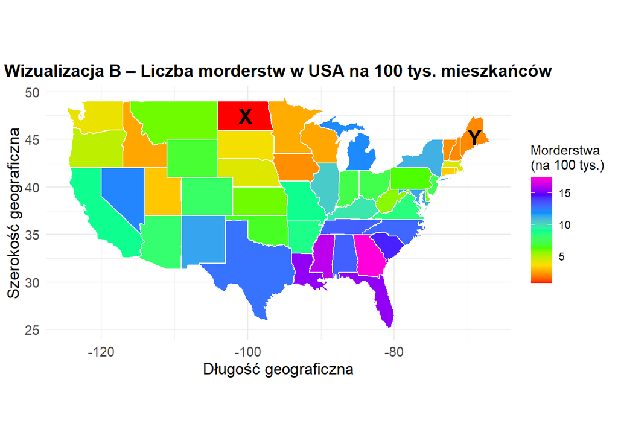

```r
ggplot(mapa_df, aes(long, lat, group = group, fill = Murder)) +
  geom_polygon(color = "white") +
  coord_fixed(1.3) +
  scale_fill_gradientn(colors = rainbow(7), name = "Morderstwa\n(na 100 tys.)") +
  labs(
    title = "Wizualizacja B – Liczba morderstw w USA na 100 tys. mieszkańców",
    x = "Długość geograficzna",
    y = "Szerokość geograficzna"
  ) +
  geom_text(data = punkty, aes(x = long, y = lat, label = label),
            inherit.aes = FALSE,
            size = 6, fontface = "bold", color = "black") +
  theme_minimal() +
  theme(
  plot.title = element_text(size = 14, face = "bold", hjust = 0.5),
  axis.title.x = element_text(size = 13),
  axis.title.y = element_text(size = 13),
  axis.text.x = element_text(size = 11),
  axis.text.y = element_text(size = 11))
```

## Wyniki ankiety

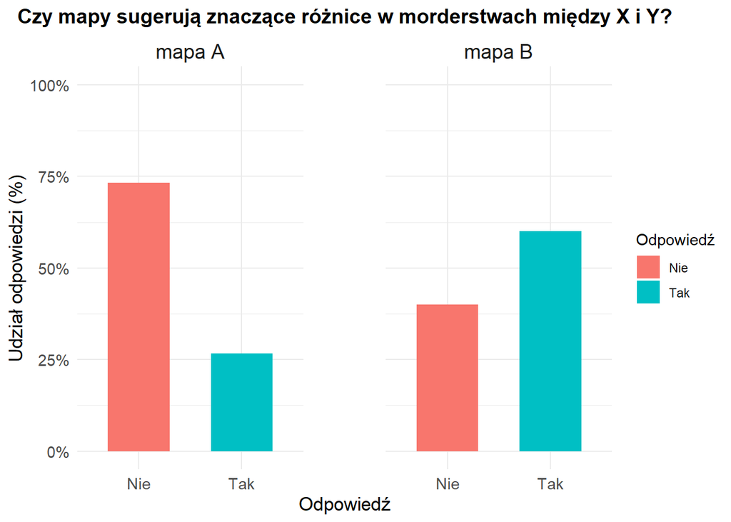

```r
ankieta = data.frame(
  mapa = rep(c("mapa A", "mapa B"), each = 2),
  odp = rep(c("Tak", "Nie"), times = 2),
  procent = c(26.7, 73.3, 60, 40) / 100)

ggplot(ankieta, aes(x = odp, y = procent, fill = odp)) +
  geom_col(width = 0.6) +
  facet_wrap(~mapa) +
  scale_y_continuous(labels = percent_format(), limits = c(0, 1)) +
  labs(
    title = "Czy mapy sugerują znaczące różnice w morderstwach między X i Y?",
    x = "Odpowiedź",
    y = "Udział odpowiedzi (%)",
    fill = "Odpowiedź"
  ) +
  theme_minimal() +
  theme(
    panel.spacing = unit(2, "cm"),
    strip.text = element_text(size = 14),
    plot.title = element_text(size = 14, face = "bold", hjust = 0.5),
    axis.title.x = element_text(size = 13),
    axis.title.y = element_text(size = 13),
    axis.text.x = element_text(size = 11),
    axis.text.y = element_text(size = 11))
```

```r
tabela = data.frame(
  pytanie = c(
    "3. Łatwość identyfikacji skrajnych wartości",
    "4. Szybkość odczytu danych",
    "5. Estetyka kolorystyki"
  ),
  `mapa A` = c("92,9%", "93,3%", "86,7%"),
  `mapa B` = c("7,1%", "6,7%", "13,3%"))

kable(tabela, format = "html", escape = FALSE, align = "lccc",
      col.names = c("pytanie", "mapa A", "mapa B")) %>%
  kable_styling(full_width = FALSE, position = 'center',
                bootstrap_options = c("striped", "hover", "condensed"),
                font_size = 14)
```

pytanie

mapa A

mapa B

3. Łatwość identyfikacji skrajnych wartości

92,9%

7,1%

4. Szybkość odczytu danych

93,3%

6,7%

5. Estetyka kolorystyki

86,7%

13,3%

Wyniki ankiety są bardzo interesujące. Na wykresie widzimy, że większość użytkowników (ponad 70%) uznała, że mapa A nie sugeruje znaczących różnic w liczbie morderstw między stanami X i Y, podczas gdy w przypadku mapy B odpowiedzi były bardziej podzielone. Mimo to, aż 60% respondentów wskazało, że mapa B z tęczową skalą sugeruje nieistniejące różnice (przeskok barwy z czerwonej na pomarańczową). W rzeczywistości liczba morderstw na 100 tysięcy mieszkańców wynosi 0,8 w stanie X oraz 2,1 w stanie Y (przy wartościach mieszczących się w przedziale od 0,8 do 17,4), co oznacza, że to kolorystyka mapy A lepiej odwzorowuje rzeczywiste różnice.

W trzech kolejnych pytaniach uczestnicy niemal jednogłośnie ocenili, że mapa A pozwala łatwiej zidentyfikować wartości skrajne, a także szybciej wyciągać wnioski. Dodatkowo jej estetyka została oceniona wyraźnie lepiej w porównaniu do mapy B.

## Wnioski

Dobór skali kolorystycznej ma istotny wpływ na interpretację danych. Uczestnicy znacznie częściej przypisywali nieistniejące różnice wizualizacji wykorzystującej skalę tęczową (mapa B). Skala monotoniczna (mapa A) o ograniczonym zakresie barw okazała się bardziej trafna i intuicyjna, zarówno pod względem poprawności interpretacji, jak i szybkości odczytu danych. Wyniki pokazują, że metoda opracowana wiele lat temu wciąż skutecznie sprawdza się wśród przeciętnych użytkowników.